# TP TD6

# Introducción al problema

En este trabajo exploramos el link entre diversos factores como el uso de redes sociales, el estres, el sueno, etc en la productividad. Es una simulacion obtenida de kaggle (https://www.kaggle.com/datasets/mahdimashayekhi/social-media-vs-productivity/data) de 30000 observaciones, con 18 variables predictoras, tanto numericas (numero de notificaciones, horas trabajadas, horas en redes, etc) como categoricas (genero, red social preferida, tipo de trabajo,etc). Intentamos predecir si una persona fue productiva o no basado en estos factores, transformando una variable numerica en binario (actual_productivity_score > 5.0). Para predecirla empezamos con un arbol naive, y luego entrenamos los hiperparametros para optimizarlo.

# 2. Preparación de los datos

## **Subir el dataset**

```r
datos <- read.csv("social_media_vs_productivity.csv")
```

Veamos si la base de datos contiene valores `NA`:

```r
table(is.na(datos))
```

```
##
##  FALSE   TRUE
## 553813  16187
```

## **Limpiamos el dataset**

En el caso para la variable objetivo actual_productivity_score, se eliminaron las filas con datos faltantes, porque es fundamental que la variable a predecir esté completa. Dado que contamos con suficientes observaciones, esta eliminación no afecta significativamente la cantidad de datos disponibles y permite obtener mejores predicciones.

En cambio, para el caso de las demas variables los valores faltantes se dejaron tal cual, ya que estamos utilizando un árbol de decisión, el cual puede manejar NA de forma nativa.

Además, creamos una nueva columna, la cual sera nuestra variable binaria a predecir, que indica si la persona es productivo ó no dependiendo si su productividad es mayór a 5.

```r
datos <- datos[!is.na(datos$actual_productivity_score), ]

table(is.na(datos))
```

```
##
##  FALSE   TRUE
## 512326  12739
```

```r
# Agregamos una nueva columna que diga si fue productivo o no, es productivo si la productividad actual es mayor a 5
library(dplyr)
datos <- mutate(datos, es_productivo = ifelse(actual_productivity_score > 5.0, "SI", "NO"))

str(datos)
```

```
## 'data.frame':    27635 obs. of  20 variables:
##  $ age                           : int  56 46 32 60 38 56 36 40 28 53 ...
##  $ gender                        : chr  "Male" "Male" "Male" "Female" ...
##  $ job_type                      : chr  "Unemployed" "Health" "Finance" "Unemployed" ...
##  $ daily_social_media_time       : num  4.18 3.25 NA NA 1.51 ...
##  $ social_platform_preference    : chr  "Facebook" "Twitter" "Twitter" "Facebook" ...
##  $ number_of_notifications       : int  61 59 57 59 50 60 49 57 57 77 ...
##  $ work_hours_per_day            : num  6.75 9.17 7.91 6.36 6.43 ...
##  $ perceived_productivity_score  : num  8.04 5.06 3.86 2.92 NA ...
##  $ actual_productivity_score     : num  7.29 5.17 3.47 1.77 4.08 ...
##  $ stress_level                  : num  4 7 4 6 5 7 4 4 4 NA ...
##  $ sleep_hours                   : num  5.12 5.1 8.58 6.05 5.52 ...
##  $ screen_time_before_sleep      : num  0.419 0.672 0.624 1.205 1.519 ...
##  $ breaks_during_work            : int  8 7 0 1 5 4 2 10 5 5 ...
##  $ uses_focus_apps               : chr  "False" "True" "True" "False" ...
##  $ has_digital_wellbeing_enabled : chr  "False" "True" "False" "False" ...
##  $ coffee_consumption_per_day    : int  4 2 3 0 5 4 4 2 1 0 ...
##  $ days_feeling_burnout_per_month: int  11 25 17 4 2 20 29 10 3 15 ...
##  $ weekly_offline_hours          : num  21.9 0 10.3 23.9 0 ...
##  $ job_satisfaction_score        : num  6.34 3.41 2.47 1.73 4.57 ...
##  $ es_productivo                 : chr  "SI" "SI" "NO" "NO" ...
```

## Analisis estadistico

### **Variables cuantitativas**

Usamos la funcion summary para obtener las estadisticas descriptivas de las variables principales del dataset. Estas medidas incluyen el minimo, el maximo, los distintos cuantiles, la cantidad de missings, la media y la mediana. Ademas agregamos las varianzas de cada una. Como se puede observar en los calculos de las varianzas hay algunas variables cuya varianza aparece como una NA, esto se debe a que al intentar hacer un calculo con un NA el resultado va a ser siempre un missing al no saber su valor.

```r
summary(datos[, c("daily_social_media_time", "work_hours_per_day", "perceived_productivity_score", "actual_productivity_score", "stress_level", "job_satisfaction_score", "age")])
```

```
##  daily_social_media_time work_hours_per_day perceived_productivity_score
##  Min.   : 0.000          Min.   : 0.000     Min.   :2.000
##  1st Qu.: 1.633          1st Qu.: 5.643     1st Qu.:3.756
##  Median : 3.028          Median : 6.988     Median :5.522
##  Mean   : 3.114          Mean   : 6.990     Mean   :5.507
##  3rd Qu.: 4.375          3rd Qu.: 8.355     3rd Qu.:7.258
##  Max.   :17.973          Max.   :12.000     Max.   :8.999
##  NA's   :2540                               NA's   :1485
##  actual_productivity_score  stress_level    job_satisfaction_score
##  Min.   :0.2968            Min.   : 1.000   Min.   : 0.000
##  1st Qu.:3.3733            1st Qu.: 3.000   1st Qu.: 3.360
##  Median :4.9517            Median : 6.000   Median : 4.945
##  Mean   :4.9518            Mean   : 5.521   Mean   : 4.958
##  3rd Qu.:6.5263            3rd Qu.: 8.000   3rd Qu.: 6.576
##  Max.   :9.8463            Max.   :10.000   Max.   :10.000
##                            NA's   :1755     NA's   :2499
##       age
##  Min.   :18.00
##  1st Qu.:30.00
##  Median :41.00
##  Mean   :41.48
##  3rd Qu.:53.00
##  Max.   :65.00
##
```

```r
var(datos$daily_social_media_time)
```

```
## [1] NA
```

```r
var(datos$work_hours_per_day)
```

```
## [1] 3.995393
```

```r
var(datos$perceived_productivity_score)
```

```
## [1] NA
```

```r
var(datos$actual_productivity_score)
```

```
## [1] 3.547113
```

```r
var(datos$stress_level)
```

```
## [1] NA
```

```r
var(datos$job_satisfaction_score)
```

```
## [1] NA
```

```r
var(datos$age)
```

```
## [1] 191.5953
```

### **Variables Binarias**

Para las variables binarias hacemos tablas de frecuencia. En el caso de la variable has_digital_wellbeing_enabled se ve la cantidad de personas que tienen activada esta funcionalidad mientras que la otra variable se ve la cantidad de personas que son productivos.

```r
table(datos$has_digital_wellbeing_enabled)
```

```
##
## False  True
## 20807  6828
```

```r
prop.table(table(datos$has_digital_wellbeing_enabled))
```

```
##
##    False     True
## 0.752922 0.247078
```

```r
table(datos$es_productivo)
```

```
##
##    NO    SI
## 14012 13623
```

```r
prop.table(table(datos$es_productivo))
```

```
##
##        NO        SI
## 0.5070382 0.4929618
```

## **Graficos**

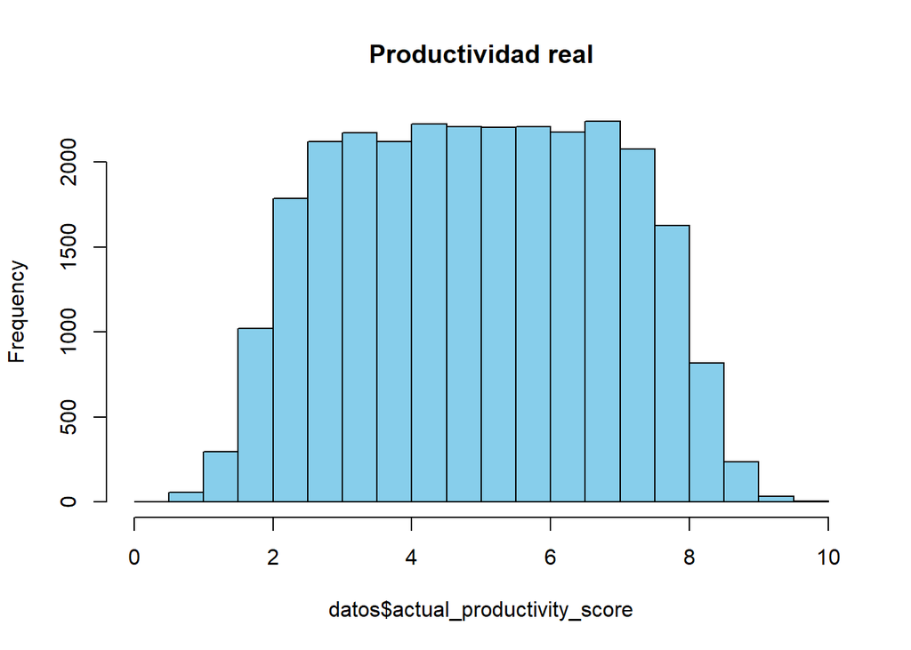

```r
hist(datos$actual_productivity_score,main="Productividad real", col="skyblue")
```

El histograma muestra la distribución del puntaje de productividad real de los usuarios. La forma es aproximadamente simétrica, con mayor concentración de valores en la zona media (entre 3 y 7), mientras que las frecuencias disminuyen hacia los extremos bajos y altos. Esto sugiere que la mayoría de los individuos tienen niveles de productividad intermedios, mientras que son pocos los que presentan productividad muy baja o muy alta.

Hacemos graficos de dispersion para ver las distintas relaciones entre algunas de las variables importantes

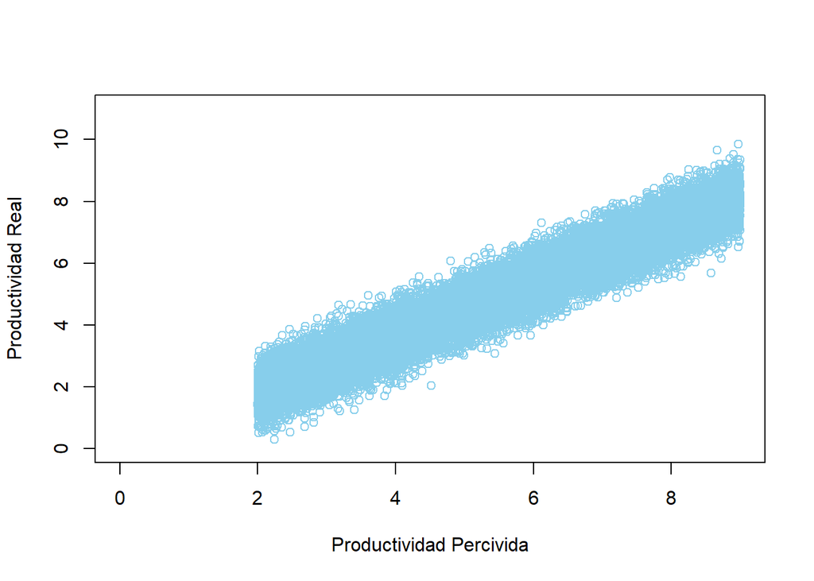

```r
plot(datos$perceived_productivity_score, datos$actual_productivity_score, ylab="Productividad Real",xlab="Productividad Percivida",main="", xlim=c(0, 9), ylim=c(0, 11), col="skyblue")
```

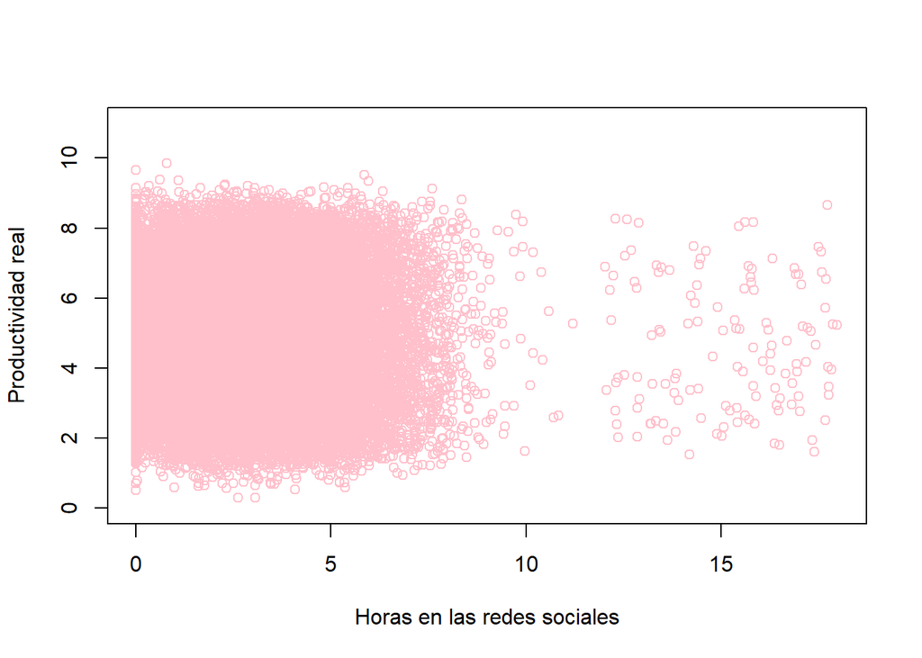

```r
plot(datos$daily_social_media_time, datos$actual_productivity_score, ylab="Productividad real",xlab="Horas en las redes sociales",main="", xlim=c(0, 18), ylim=c(0, 11), col="pink")
```

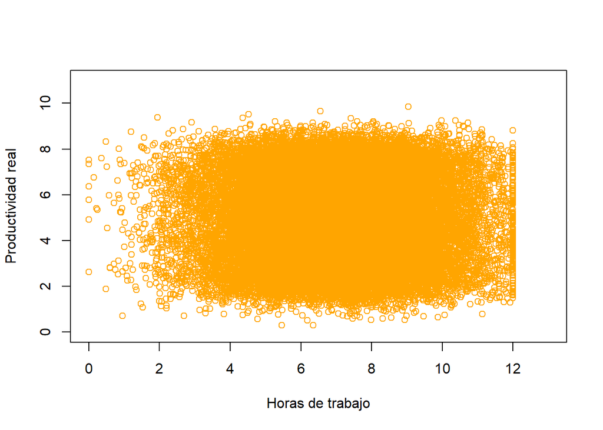

```r
plot(datos$work_hours_per_day, datos$actual_productivity_score, ylab="Productividad real", xlab="Horas de trabajo",main="", xlim=c(0, 13), ylim=c(0, 11),col="orange")
```

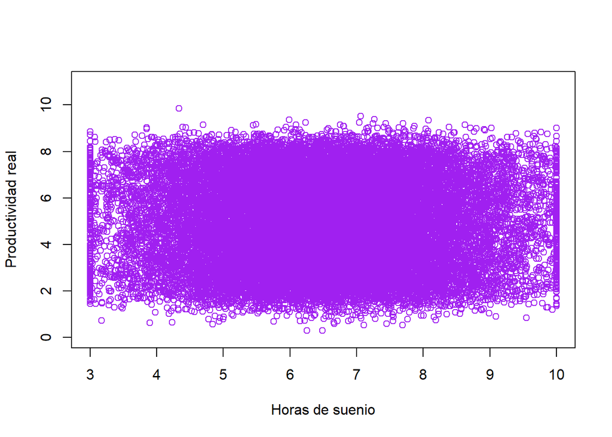

```r
plot(datos$sleep_hours, datos$actual_productivity_score, ylab="Productividad real", xlab="Horas de suenio",main="", xlim=c(3, 10), ylim=c(0, 11), col="purple")
```

En los gráficos se observan diferentes factores asociados a la productividad real. En el primer gráfico, la productividad percibida muestra una relación positiva y bastante clara con la productividad real, lo que indica que quienes creen ser más productivos, en general, efectivamente lo son.

En el tercer gráfico, las horas de trabajo por día tampoco muestran una relación lineal fuerte con la productividad real, ya que los puntos están muy dispersos y no hay un patrón definido.

# 3. Construcción de un árbol de decisión básico

Hacemos la division de los datos con las proporciones correspondientes en los 3 conjuntos distintos, el conjunto de training, de testing y de validation. Seteamos una semilla para asegurar la replicabilidad.

```r
set.seed(22)  # Semilla para que siempre salga igual si volvés a correrlo

datos <- subset(datos, select = -actual_productivity_score)



n <- nrow(datos)

# Mezclar aleatoriamente los índices
indices <- sample(1:n)

# Proporciones
n_train <- round(0.70 * n)
n_valid <- round(0.15 * n)
n_test  <- n - n_train - n_valid  # lo que quede

# Particiones
train_indices <- indices[1:n_train]
valid_indices <- indices[(n_train + 1):(n_train + n_valid)]
test_indices  <- indices[(n_train + n_valid + 1):n]

# Subsets finales
train <- datos[train_indices, ]
valid <- datos[valid_indices, ]
test  <- datos[test_indices, ]
```

Se convierten estas variables en factores porque representan categorías y no valores numéricos continuos. De esta forma, R las interpreta correctamente como cualitativas al momento de analizarlas o usarlas en un modelo. Esto evita que el algoritmo las trate como números con un orden o magnitud inexistente.

```r
train$has_digital_wellbeing_enabled<-as.factor(train$has_digital_wellbeing_enabled)
train$gender  <- as.factor(train$gender)
train$job_type <- as.factor(train$job_type)
train$social_platform_preference <- as.factor(train$social_platform_preference)
train$uses_focus_apps <- as.factor(train$uses_focus_apps)
# Convertir a factor
train$es_productivo <- factor(train$es_productivo)
test$es_productivo  <- factor(test$es_productivo)
```

```r
train
```

[output not shown]

[output cut: 9990 more lines]

## Contrucción del árbol basico

Dejamos los hiperparametros por defecto, eston son:

- maxdepth = 30 implica que el árbol no puede tener más de 30 niveles.
- minsplit = 20 implica que un nodo debe tener al menos 20 casos para dividirse.
- minbucket = 7 implica que cada hoja terminal debe tener al menos 7 observaciones.
- cp = 0.01 implica que una división se acepta solo si mejora el ajuste en un 1%.
- xval = 10 implica que se hace cross validation de 10 particiones para estimar error y podar el árbol.

```r
library(rpart)


tree <- rpart(
  formula =  es_productivo ~ age + perceived_productivity_score + daily_social_media_time + work_hours_per_day + stress_level + has_digital_wellbeing_enabled + job_satisfaction_score,
  data = train,
  method = "class"
)
```

## Grafico del arbol

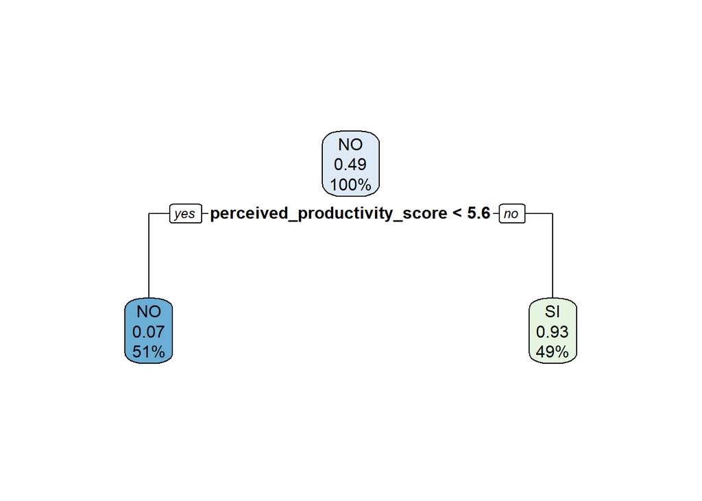

```r
# install.packages("rpart.plot") # Descomentar si no lo tienen ya instalado.
library(rpart.plot)
rpart.plot(tree)
```

El árbol de decisión entrenado con las variables seleccionadas muestra que la más influyente para predecir si una persona es productiva o no es el perceived_productivity_score. El modelo establece un umbral en 5.6: cuando el puntaje de productividad percibida es menor a 5.6, la mayoría de los casos se clasifican como no productivos (51%). En cambio, cuando el puntaje es mayor o igual a 5.6, la predicción se inclina fuertemente hacia si productivo, concentrando el 49% de los casos. Esto indica que, a pesar de haber considerado variables como edad, tiempo en redes sociales, horas de trabajo, nivel de estrés, satisfacción laboral y uso de bienestar digital, el árbol decidió que la única variable relevante en la primera división es la productividad percibida (Debido a que la variable a predecir fue armada en base a los valores de actual_productivity_score, se decidio no inncluir esta en el entrenamiento del modelo, ya que si no el arbol solo depende de esta variable y seria un caso de data leakage). En otras palabras, el modelo encontró que este puntaje es el factor más determinante para distinguir entre personas productivas y no productivas en el conjunto de datos.

# 4. Evaluación del árbol de decisión básico

```r
test$has_digital_wellbeing_enabled<-as.factor(test$has_digital_wellbeing_enabled)
test$gender  <- as.factor(test$gender)
test$job_type <- as.factor(test$job_type)
test$social_platform_preference <- as.factor(test$social_platform_preference)
test$uses_focus_apps <- as.factor(test$uses_focus_apps)
```

Hacemos las predicciones en el conjunto de testeo, calculando las probabilidades predichas y las clases predichas

```r
predictions_prob  <- predict(tree, newdata = test, type="prob")
predictions_class <- predict(tree, newdata = test, type="class")
```

```r
# predictions_prob
```

```r
# Accuracy
library(MLmetrics)
Accuracy(y_pred = predictions_class, y_true = test$es_productivo)
```

```
## [1] 0.9307767
```

```r
ConfusionMatrix(y_pred = predictions_class, y_true = test$es_productivo)
```

```
##       y_pred
## y_true   NO   SI
##     NO 1954  139
##     SI  148 1905
```

```r
F1_Score(y_true=test$es_productivo, y_pred = predictions_class, positive = "SI")
```

```
## [1] 0.9299487
```

```r
Precision(y_true=test$es_productivo, y_pred = predictions_class, positive ="SI" )
```

```
## [1] 0.9319961
```

```r
Recall(y_true=test$es_productivo, y_pred = predictions_class, positive = "SI")
```

```
## [1] 0.9279104
```

```r
AUC(y_pred = predictions_prob[, "SI"],y_true = ifelse(test$es_productivo == "SI", 1, 0))
```

```
## [1] 0.9307493
```

Los resultados del modelo muestran un desempeño muy elevado en todas las métricas de evaluación. La exactitud alcanza aproximadamente un 93%, con un F1-Score y valores de precisión y recall también cercanos al 93%. La matriz de confusión refleja un buen equilibrio en la clasificación de ambas clases, con pocos falsos positivos y falsos negativos en comparación con la cantidad total de observaciones.

Estos valores tan altos son coherentes con el hecho de que el dataset utilizado es sintético, lo cual reduce la complejidad del problema y facilita que el modelo aprenda patrones de manera más precisa, en comparación con datos reales donde suele aparecer más ruido.

# Optimización del modelo

Usamos el random search para optimizar los hiperparametros, ya que esta funcion combina de forma aleatoria los valores de max_depth, min_split y min_bucket, en los rangos que le indiquemos, buscando optimizar el valor del AUC-ROC en cada iteracion.

```r
train_tree <- function(train_data, max_depth, min_split, min_bucket){
  tree <- rpart(es_productivo ~ age + perceived_productivity_score + daily_social_media_time + work_hours_per_day + stress_level + has_digital_wellbeing_enabled + job_satisfaction_score,
                data = train_data,
                method = "class",
                maxdepth = max_depth,
                minsplit = min_split,
                minbucket = min_bucket,
                cp = 0,
                xval = 0)
  return (tree)
}

randSearch <- function(train, valid, maxdepth_hasta, minsplit_hasta, minbucket_hasta, n_iter) {


  mejor_auc <- 0
  aucs <- c()
  max_ds<- c()
  min_ss <- c()
  min_bs <- c()


  for (i in 1:n_iter) {

    max_d <- sample(1:maxdepth_hasta, 1) #elige solo un numero rand del conjunto
    min_s <- sample(1:minsplit_hasta, 1)
    min_b <- sample(1:minbucket_hasta, 1)

    tree <- train_tree(train, max_d, min_s, min_b)
    pred <- predict(tree, newdata = valid, type = "prob")

    auc <- AUC(y_pred = pred[, "SI"], y_true = ifelse(valid$es_productivo == "SI", 1, 0))

    aucs<- c(aucs, auc)
    max_ds<- c(max_ds, max_d)
    min_ss <- c(min_ss, min_s)
    min_bs <- c(min_bs, min_b)
  }

  return(data.frame(maxdepth = max_ds, minsplit = min_ss, minbucket = min_bs, AUC = aucs))
}
```

Realizada la random search, graficamos la relación de cada una de los hiperparámetros con el AUC del árbol.

| maxdepth | minsplit | minbucket | AUC |
| --- | --- | --- | --- |
| 20 | 5 | 21 | 0.9759584 |
| 24 | 37 | 23 | 0.9762450 |
| 17 | 19 | 11 | 0.9728031 |
| 7 | 11 | 8 | 0.9759989 |
| 13 | 9 | 37 | 0.9740449 |
| 18 | 4 | 12 | 0.9745301 |
| 14 | 28 | 27 | 0.9762959 |
| 28 | 11 | 1 | 0.9386262 |
| 20 | 31 | 33 | 0.9740101 |
| 2 | 13 | 7 | 0.9305056 |

[output cut: 40 more lines]

|  | maxdepth | minsplit | minbucket | AUC |
| --- | --- | --- | --- | --- |
| 23 | 1 | 34 | 40 | 0.9305056 |
| 10 | 2 | 13 | 7 | 0.9305056 |
| 11 | 6 | 22 | 31 | 0.9741141 |
| 19 | 6 | 33 | 31 | 0.9741141 |
| 32 | 6 | 38 | 40 | 0.9741259 |
| 44 | 6 | 38 | 21 | 0.9696626 |
| 4 | 7 | 11 | 8 | 0.9759989 |
| 28 | 7 | 10 | 5 | 0.9780087 |
| 22 | 8 | 2 | 38 | 0.9740659 |
| 24 | 8 | 8 | 13 | 0.9758864 |

[output cut: 40 more lines]

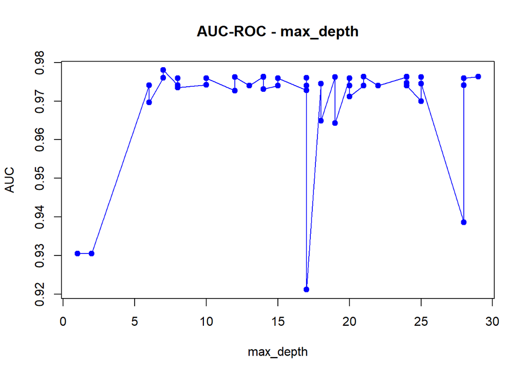

En general, el modelo parece alcanzar un buen equilibrio de desempeño con profundidades intermedias (entre 6 y 15), sin que profundidades mayores generen mejoras consistentes. Esto sugiere que profundizar demasiado el árbol no aporta beneficios claros y puede incluso introducir inestabilidad.

|  | maxdepth | minsplit | minbucket | AUC |
| --- | --- | --- | --- | --- |
| 45 | 12 | 1 | 23 | 0.9762450 |
| 22 | 8 | 2 | 38 | 0.9740659 |
| 29 | 22 | 3 | 33 | 0.9740101 |
| 31 | 14 | 4 | 10 | 0.9730473 |
| 42 | 17 | 4 | 1 | 0.9211809 |
| 6 | 18 | 4 | 12 | 0.9745301 |
| 26 | 19 | 5 | 25 | 0.9762182 |
| 1 | 20 | 5 | 21 | 0.9759584 |
| 49 | 29 | 5 | 29 | 0.9762984 |
| 40 | 8 | 6 | 2 | 0.9734697 |

[output cut: 40 more lines]

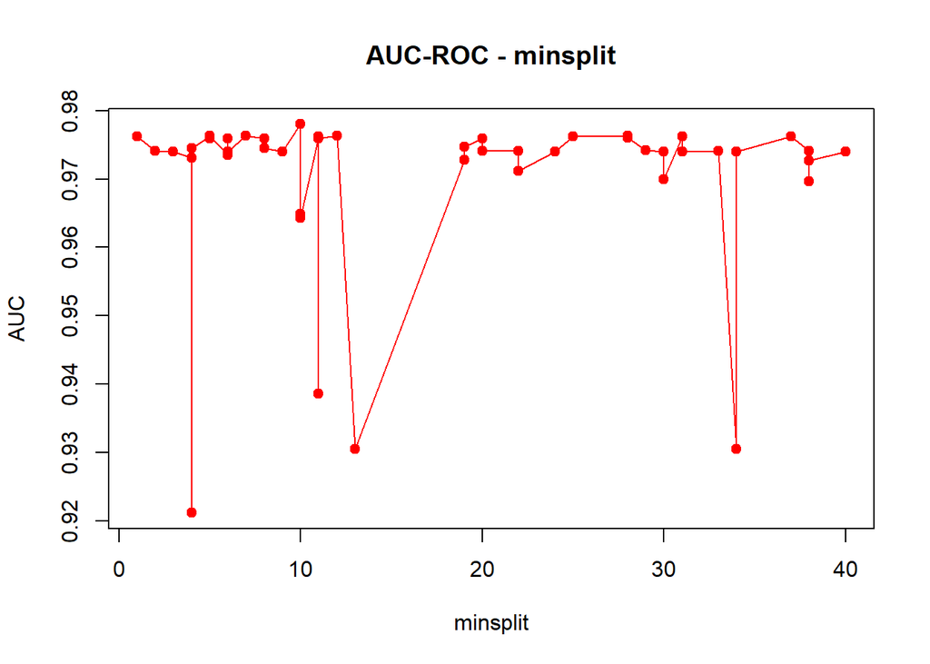

Este gráfico muestra la relación entre el parámetro minsplit y el desempeño medido con AUC-ROC. Se observa que en la mayoría de los valores de minsplit el modelo alcanza niveles de AUC muy altos (entre 0.96 y 0.98 aproximadamente), lo que indica que el rendimiento es bastante estable. Sin embargo, existen algunos valores puntuales de minsplit que generan caídas fuertes en el AUC (por ejemplo, alrededor de 4, 11–13 y 34), lo que sugiere que en esos casos el árbol se construye con divisiones poco adecuadas y se reduce la capacidad predictiva.

En general, podemos decir que el parámetro minsplit no parece tener un efecto fuerte sobre el desempeño, salvo en esos valores específicos donde provoca inestabilidad. Por lo tanto, sería razonable elegir un rango medio de minsplit para evitar esas caídas y mantener el AUC en valores cercanos al óptimo.

|  | maxdepth | minsplit | minbucket | AUC |
| --- | --- | --- | --- | --- |
| 42 | 17 | 4 | 1 | 0.9211809 |
| 8 | 28 | 11 | 1 | 0.9386262 |
| 40 | 8 | 6 | 2 | 0.9734697 |
| 21 | 10 | 29 | 3 | 0.9742276 |
| 39 | 25 | 30 | 3 | 0.9699945 |
| 28 | 7 | 10 | 5 | 0.9780087 |
| 43 | 19 | 10 | 5 | 0.9642658 |
| 34 | 18 | 10 | 6 | 0.9649313 |
| 33 | 12 | 38 | 6 | 0.9726440 |
| 10 | 2 | 13 | 7 | 0.9305056 |

[output cut: 40 more lines]

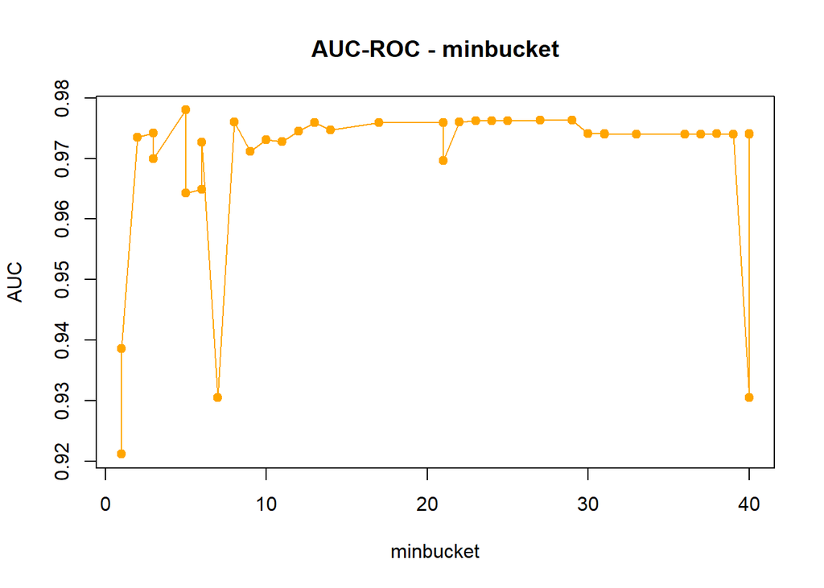

En el gráfico se observa la relación entre el hiperparámetro minbucket y el desempeño medido con AUC-ROC. El rendimiento del modelo se mantiene en valores muy altos (aproximadamente 0.97) para la mayoría de los valores de minbucket, mostrando estabilidad y robustez. Sin embargo, al igual que en los otros parámetros, existen valores puntuales que generan caídas marcadas en el AUC, especialmente en los extremos y en algunos valores bajos, lo cual refleja que configuraciones demasiado restrictivas o demasiado permisivas en el tamaño mínimo de los nodos pueden afectar negativamente la capacidad predictiva.

# Conclusion general de los graficos

Al analizar en conjunto los tres parámetros (minsplit, maxdepth y minbucket), podemos concluir que el modelo alcanza niveles de desempeño muy altos y relativamente estables para un rango amplio de valores. Esto indica que el modelo es robusto frente a variaciones moderadas en la configuración de hiperparámetros. Sin embargo, en los tres casos se identifican ciertos valores específicos que generan caídas significativas en el AUC, lo que sugiere la importancia de evitar extremos o combinaciones poco equilibradas. En general, se recomienda optar por valores intermedios de los parámetros para garantizar una buena estabilidad y capacidad predictiva.

## Mejor rendimiento

El AUC-ROC despues de probar el conjunto de entrenamiento con el nuevo modelo:

```r
mejor_auc
```

```
## [1] 0.976441
```

```r
library(pROC)
# Generamos predicciones de probabilidad sobre el set de test
predicciones <- predict(mejor_arbol, newdata = test, type = "prob")[, "SI"]

# Creamos el objeto ROC
roc_obj <- roc(test$es_productivo, predicciones)
```

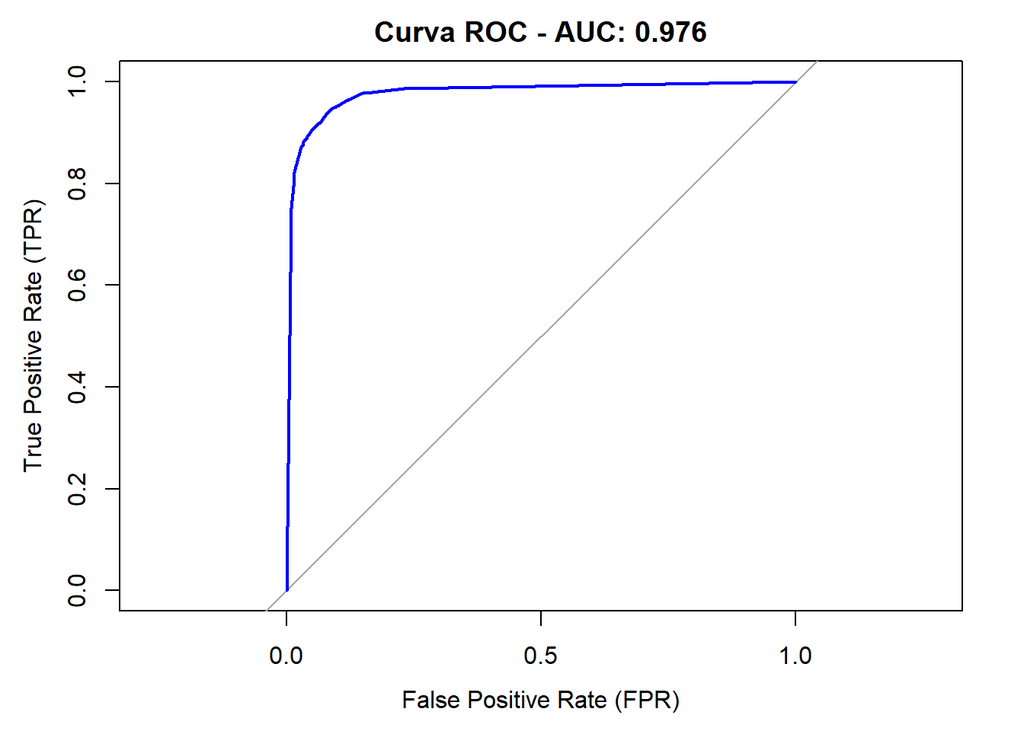

```r
plot(
  roc_obj,
  col = "blue",
  lwd = 2,
  main = paste("Curva ROC - AUC:", round(auc(roc_obj), 3)),
  legacy.axes = TRUE,
  xlab = "False Positive Rate (FPR)",
  ylab = "True Positive Rate (TPR)"
)
```

La curva ROC muestra un desempeño sobresaliente del modelo, con un AUC de 0.976, muy cercano a 1. Esto indica que tiene una excelente capacidad para discriminar entre observaciones positivas y negativas. La curva se eleva rápidamente, lo cual refleja una alta tasa de positivos verdaderos (TPR) incluso con bajos niveles de falsos positivos (FPR). En términos prácticos, el modelo logra una clasificación muy precisa, minimizando tanto los errores de tipo I como los de tipo II.

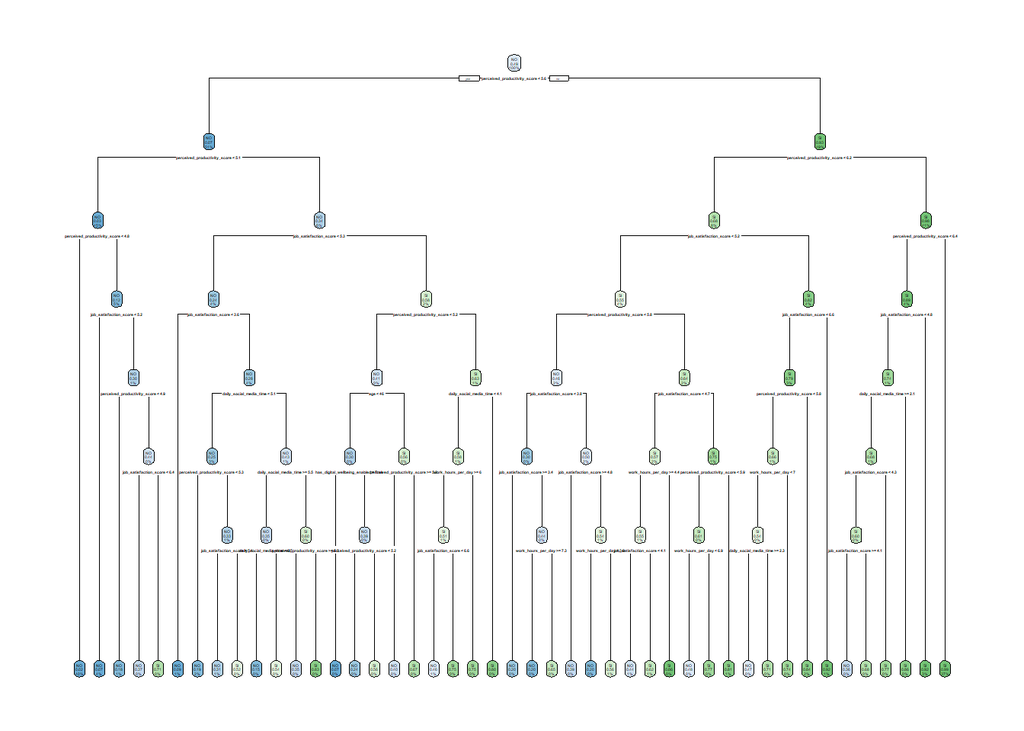

```r
rpart.plot(mejor_arbol, roundint = FALSE)
```

# 5. Interpretacion de resultados

El árbol de decisión muestra que la variable más importante para predecir si alguien es productivo es el perceived_productivity_score, ya que aparece en la raíz y en varios niveles del árbol. En segundo lugar, también se destaca el job_satisfaction_score, que ayuda a separar los casos en distintos grupos. Otras variables que tienen influencia son las work_hours_per_day y el daily_social_media_time, aunque aparecen más en ramas específicas. Finalmente, el stress_level tiene un peso menor, pero aporta información en algunos nodos. En resumen, la productividad percibida y la satisfacción laboral son las variables principales, mientras que las demás variables suman detalles que mejoran la clasificación en ciertos casos.

Como dejamos el cp y xval en 0, cp va a dejar que el arbol cresca sin restriccion de la complexidad lo cual hace que el arbol optimizado se vea mas profundo que el arbol base, y como el xval no vamos a hacer cross validation lo que tiene sentido porque ya tenemos un conjunto de validacion entonces no es necesario. Al compararlo con el arbol del punto 3, podemos ver que es más profundo y se amplia más, esto se debe a que cambiamos los valores default que restringian el modelo.

```
## perceived_productivity_score       job_satisfaction_score
##                  6961.429543                  3871.732879
##                          age           work_hours_per_day
##                    12.303421                     3.075855
```

```
##  perceived_productivity_score        job_satisfaction_score
##                   7520.683005                   4054.557621
##            work_hours_per_day       daily_social_media_time
##                     31.205144                     24.831895
##                           age has_digital_wellbeing_enabled
##                     19.576290                      2.831751
##                  stress_level
##                      1.346414
```

El árbol inicial sin optimizar era muy simple: solo usaba la variable perceived_productivity_score para dividir los casos. Si el valor era menor a 5.6, la mayoría se clasificaba como “NO productivo”, y si era mayor o igual, se clasificaba como “SÍ productivo”. Esto hacía que el árbol sea fácil de interpretar, pero dejaba afuera mucha información de las demás variables.

En cambio, el árbol optimizado final es más complejo y aprovecha otras variables, como el job_satisfaction_score, las work_hours_per_day y el daily_social_media_time, lo que le permite separar mejor los casos. Gracias a eso, el modelo logra una clasificación más precisa y un mejor ajuste, ya que no depende solo de una variable. Ademas que aumente la importancia de las variables que aparecian en el primer árbol.

# 6. Análisis del impacto de etiquetas corruptas

```r
corromper <- function(train, p) {
  n <- nrow(train)
  n_corrupt <- round(p * n)
  indices <- sample(1:n, n_corrupt)

  train$es_productivo[indices] <- ifelse(
    train$es_productivo[indices] == "SI", "NO", "SI"
  )

  return(train)
}
```

```r
resultados_aucs <- list()
set.seed(22)
porcent <- c(0.05,0.1,0.15,0.2,0.25,0.3)

for (p in porcent) {
  aucs_iteracion <- c()
  for (i in 1:10) { # Bucle para 10 iteraciones
    ver_p <- corromper(train, p)
    mejor_arbol_p <- opt_model(ver_p, valid)
    mejor_auc_p <- test_model(mejor_arbol_p, test)
    aucs_iteracion <- c(aucs_iteracion, mejor_auc_p)
  }
  resultados_aucs[[as.character(p)]] <- aucs_iteracion
}

# Calcular medias y desviaciones estándar
medias_aucs <- sapply(resultados_aucs, mean)
desv_std_aucs <- sapply(resultados_aucs, sd)

# Añadir los resultados del 0% de corrupción
total <- c(0, porcent)
medias_aucs_total <- c(mejor_auc, medias_aucs)
desv_std_aucs_total <- c(0, desv_std_aucs) # Desviación estándar es 0 para el caso sin corrupción
```

```r
# Crear un dataframe para el gráfico con ggplot2
df_plot <- data.frame(
  porcentaje_corrupta = total,
  media_auc = medias_aucs_total,
  desv_std = desv_std_aucs_total
)
df_plot
```

|  | porcentaje_corrupta | media_auc | desv_std |
| --- | --- | --- | --- |
|  | 0.00 | 0.9764410 | 0.000000000 |
| 0.05 | 0.05 | 0.9740372 | 0.002908674 |
| 0.1 | 0.10 | 0.9722123 | 0.009184413 |
| 0.15 | 0.15 | 0.9726213 | 0.008372766 |
| 0.2 | 0.20 | 0.9664096 | 0.011931995 |
| 0.25 | 0.25 | 0.9721195 | 0.003849975 |
| 0.3 | 0.30 | 0.9665509 | 0.004836111 |

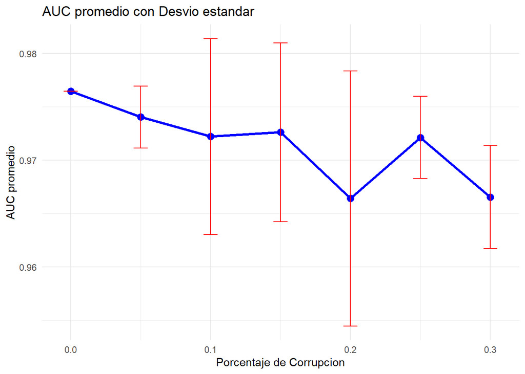

```r
library(ggplot2)
# Graficar los resultados
ggplot(df_plot, aes(x = porcentaje_corrupta, y = media_auc)) +
  geom_line(color = "blue", linewidth = 1.2) +
  geom_point(color = "blue", size = 3) +
  geom_errorbar(aes(ymin = media_auc - desv_std, ymax = media_auc + desv_std),
                width = 0.01, color = "red") +
  labs(x = "Porcentaje de Corrupcion", y = "AUC promedio",
       title = "AUC promedio con Desvio estandar") +
  theme_minimal()
```

La corrupción de obervaciones muestra que la performance disminuye a medida que aumenta el porcentaje de etiquetas corruptas, pero no de manera estrictamente lineal. El modelo es robusto hasta cierto punto de ruido (hasta un 10%), con AUC solo ligeramente inferior al máximo de 0.976. A medida que aumenta el porcentaje de etiquetas corruptas, el desempeño disminuye, alcanzando AUC alrededor de 0.96–0.97 para corrupciones del 20–30%, mostrando la mayor desviacion con la corrupcioin del 20%. Las pequeñas subidas y bajadas observadas entre porcentajes consecutivos reflejan la aleatoriedad de la selección de observaciones corruptas, que en algunas iteraciones altera menos en los valores mas importante del modelo. .

# Conclusion

El árbol de decisión, tanto en su versión básica como optimizada, demostró ser una herramienta muy efectiva para clasificar individuos productivos y no productivos. El árbol inicial identificó de manera clara que la productividad percibida es la variable más determinante. La optimización de hiperparámetros permitió incorporar otras variables relevantes, como satisfacción laboral, horas de trabajo y tiempo en redes sociales, mejorando la capacidad predictiva del modelo. El desempeño del árbol optimizado aumento en un 4.6% el AUC-ROC de su version basica.

Aunque los resultaron fueron muy buenos, es importante destacar que el dataset es sintético, lo que reduce la complejidad y el ruido comparado con datos reales. Por lo tanto, estos numeros podrían variar en escenarios reales. Para mejorar el análisis, se podrían explorar otros modelos para conpararlos con el resultado del arbol de decision, realizar validación cruzada más exhaustiva.

En resumen, los árboles de decisión resultaron ser herramientas interpretables y efectivas para este problema, capaces de identificar las variables clave que influyen en la productividad.